# Biostat 212A Homework 3

Due Feb 18, 2025 @ 11:59PM

Author

Nathaniel Boyle and 006525153

Published

February 18, 2025

## 1 ISL Exercise 5.4.2 (10pts)

We will now derive the probability that a given observation is part of a bootstrap sample. Suppose that we obtain a bootstrap sample from a set of n observations.

1. What is the probability that the first bootstrap observation is not the jth observation from the original sample? Justify your answer.

Total Observations: There are $n$ observations in the original sample.

When drawing the first observation for the bootstrap sample, each of the $n$ observations has an equal probability of being chosen.

The probability that the first bootstrap observation is the j-th observation is:
$$𝑃=\frac{1}{n}$$

Thus the probability of not selecting that j-th observation is
$$P=1-\frac{1}{n}$$

2. What is the probability that the second bootstrap observation is not the jth observation from the original sample?

Since the bootstrap sampling is done with replacement, the probability distribution of the second observation is identical to the first.

Thus the probability that the second bootstrap observation is not from the original sample is:
$$P=1-\frac{1}{n}$$

This is the same as the probability for the first observation.

3. Argue that the probability that the jth observation is not in the bootstrap sample is $(1 − 1/n)^n$.

Since each bootstrap observation is done with replacement, and since we have already shown in part (a) and (b) that the probability is $P=1-\frac{1}{n}$ we can extrapolate this result to all draws of $n$

Thus
$$P=(1-\frac{1}{n})^{n}$$

4. When n = 5, what is the probability that the jth observation is in the bootstrap sample?

Plug in our value for $n=5$ and recognize we want the probability of the bootstrap being the same as the observation, thus we will do $1-P(j*)$ where $P(j*)$ is the probability of **not** getting the j-th observation in the bootstrap sample. Thus,

$$P(j)=1-P(j*)=1-(1-\frac{1}{n})^{n}$$
Plug in values for $n$

$$P(j)=1-(1-\frac{1}{5})^5=0.67232$$
Therefore our probability that the jth observation is in the bootstrap sample when $n=5$ is about $67.23\%$.

5. When n = 100, what is the probability that the jth observation is in the bootstrap sample?

Same steps, now with $n=100$

$$P(j)=1-(1-\frac{1}{100})^{100}=0.6339$$

6. When n = 10, 000, what is the probability that the jth observation is in the bootstrap sample?

Same steps, now with $n=100$

$$P=1-(1-\frac{1}{10000})^{10000}=0.63213$$

7. Create a plot that displays, for each integer value of n from 1 to 100, 000, the probability that the jth observation is in the bootstrap sample. Comment on what you observe.

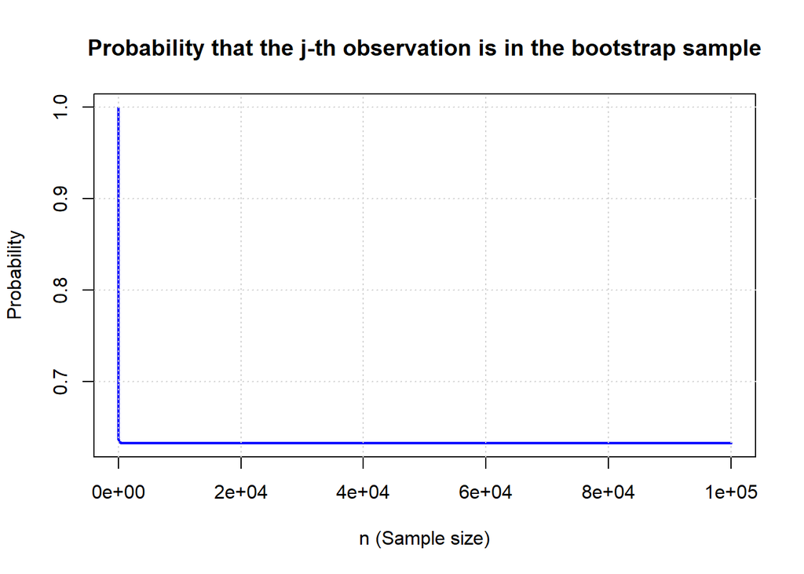

```r
# create a plot that shows the probability of getting bootstrap sample from n=1
# to n=100

# Define the function to calculate the probability
probability_in_bootstrap <- function(n) {
  return(1 - (1 - 1/n)^n)
}

# Generate a sequence of n from 1 to 100,000
n_values <- 1:100000

# Calculate the probabilities for each n
probabilities <- sapply(n_values, probability_in_bootstrap)

# Plot the result
plot(n_values, probabilities, type = "l", col = "blue", lwd = 2,
     xlab = "n (Sample size)", ylab = "Probability",
     main = "Probability that the j-th observation is in the bootstrap sample")
grid()
```

8. We will now investigate numerically the probability that a bootstrap sample of size n = 100 contains the jth observation. Here j = 4. We repeatedly create bootstrap samples, and each time we record whether or not the fourth observation is contained in the bootstrap sample.

```r
store <- rep(NA, 10000)
for(i in 1:10000){
store[i] <- sum(sample(1:100, rep=TRUE) == 4) > 0
 }

mean(store)
```

```
[1] 0.6287
```

## 2 ISL Exercise 5.4.9 (20pts)

We will now consider the Boston housing data set, from the ISLR2 library.

1. Based on this data set, provide an estimate for the population mean of medv. Call this estimate µˆ.

```r
# Load the ISLR2 library
library(ISLR2)

# Calculate the sample mean of medv
mean_medv <- mean(Boston$medv)

# Print the result
mean_medv
```

```
[1] 22.53281
```

2. Provide an estimate of the standard error of µˆ. Interpret this result.

```r
# Calculate the standard deviation of medv
sd_medv <- sd(Boston$medv)

# Get the number of observations in the dataset
n <- nrow(Boston)

# Calculate the standard error of the mean
se_medv <- sd_medv / sqrt(n)

# Print the result
se_medv
```

```
[1] 0.4088611
```

Hint: We can compute the standard error of the sample mean by dividing the sample standard deviation by the square root of the number of observations.

3. Now estimate the standard error of µˆ using the bootstrap. How does this compare to your answer from (b)?

```r
# Set a seed for reproducibility
set.seed(123)

# Define the number of bootstrap samples
n_bootstrap <- 1000

# Initialize a vector to store bootstrap means
bootstrap_means <- numeric(n_bootstrap)

# Perform the bootstrap procedure
for (i in 1:n_bootstrap) {
  # Resample the data with replacement
  bootstrap_sample <- sample(Boston$medv, size = n, replace = TRUE)

  # Compute the mean of the bootstrap sample
  bootstrap_means[i] <- mean(bootstrap_sample)
}

# Estimate the standard error using the bootstrap
se_bootstrap <- sd(bootstrap_means)

# Print the bootstrap standard error
se_bootstrap
```

```
[1] 0.4185474
```

4. Based on your bootstrap estimate from (c), provide a 95 % confidence interval for the mean of medv. Compare it to the results obtained using t.test(Boston$medv). Hint: You can approximate a 95 % confidence interval using the formula [ˆµ − 2SE(ˆµ), µˆ + 2SE(ˆµ)].

```r
# Calculate the sample mean of medv (from part a)
mean_medv <- mean(Boston$medv)

# Construct the 95% confidence interval using the bootstrap estimate of SE
lower_bound <- mean_medv - 2 * se_bootstrap
upper_bound <- mean_medv + 2 * se_bootstrap

# Print the 95% confidence interval
lower_bound
```

```
[1] 21.69571
```

```r
upper_bound
```

```
[1] 23.3699
```

```r
# Perform a t-test to calculate the confidence interval
t_test_result <- t.test(Boston$medv)

# Print the 95% confidence interval from the t-test
t_test_result$conf.int
```

```
[1] 21.72953 23.33608
attr(,"conf.level")
[1] 0.95
```

5. Based on this data set, provide an estimate, µˆmed, for the median value of medv in the population.

```r
# Calculate the sample median of medv
median_medv <- median(Boston$medv)

# Print the result
median_medv
```

```
[1] 21.2
```

6. We now would like to estimate the standard error of µˆmed. Unfortunately, there is no simple formula for computing the standard error of the median. Instead, estimate the standard error of the median using the bootstrap. Comment on your findings.

```r
# Set a seed for reproducibility
set.seed(123)

# Define the number of bootstrap samples
n_bootstrap <- 1000

# Initialize a vector to store bootstrap medians
bootstrap_medians <- numeric(n_bootstrap)

# Perform the bootstrap procedure
for (i in 1:n_bootstrap) {
  # Resample the data with replacement
  bootstrap_sample <- sample(Boston$medv, size = n, replace = TRUE)

  # Compute the median of the bootstrap sample
  bootstrap_medians[i] <- median(bootstrap_sample)
}

# Estimate the standard error using the bootstrap
se_median_bootstrap <- sd(bootstrap_medians)

# Print the bootstrap standard error for the median
se_median_bootstrap
```

```
[1] 0.3852428
```

7. Based on this data set, provide an estimate for the tenth percentile of medv in Boston census tracts. Call this quantity µˆ0.1. (You can use the quantile() function.)

```r
# Calculate the 10th percentile of medv
percentile_10th <- quantile(Boston$medv, 0.1)

# Print the result
percentile_10th
```

```
  10%
12.75
```

8. Use the bootstrap to estimate the standard error of µˆ0.1. Comment on your findings.

```r
# Set a seed for reproducibility
set.seed(123)

# Define the number of bootstrap samples
n_bootstrap <- 1000

# Initialize a vector to store bootstrap 10th percentiles
bootstrap_percentiles_10th <- numeric(n_bootstrap)

# Perform the bootstrap procedure
for (i in 1:n_bootstrap) {
  # Resample the data with replacement
  bootstrap_sample <- sample(Boston$medv, size = n, replace = TRUE)

  # Compute the 10th percentile of the bootstrap sample
  bootstrap_percentiles_10th[i] <- quantile(bootstrap_sample, 0.1)
}

# Estimate the standard error using the bootstrap
se_percentile_10th_bootstrap <- sd(bootstrap_percentiles_10th)

# Print the bootstrap standard error for the 10th percentile
se_percentile_10th_bootstrap
```

```
[1] 0.5054028
```

## 3 Least squares is MLE (10pts)

Show that in the case of linear model with Gaussian errors, maximum likelihood and least squares are the same thing, and $C_p$ and AIC are equivalent.

## 4 ISL Exercise 6.6.1 (10pts)

We perform best subset, forward stepwise, and backward stepwise selection on a single data set. For each approach, we obtain p + 1 models, containing 0, 1, 2,…,p predictors. Explain your answers:

1. Which of the three models with k predictors has the smallest training RSS?

Best Subset Selection will yield the model with the smallest training RSS

Best Subset Selection considers all possible combinations of predictors and selects the one that minimizes the training RSS for each value of $k$. Any given number of predictors, the Best Subset method will choose the best possible model (in terms of training RSS) from all combinations.

2. Which of the three models with k predictors has the smallest test RSS?

Stepwise models. Stepwise models prevent overfitting due to their constraints.

1. True
2. True
3. False
4. False
5. False

## 5 ISL Exercise 6.6.3 (10pts)

For parts (a) through (e), indicate which of i. through v. is correct. Justify your answer.

1. We start from 0, meaning we start with the least flexible and most restricted model. We will end with the least squares model. As the model gets more flexible, the training RSS will decrease slowly.

ii is Correct. The RSS decreases as we increase $s$ due to the model having more flexibility

ii is correct. For a test RSS the Test RSS will initially decrease and then start increasing as the model gets more flexible and starts to overfit the training data.

iii is correct. As $s$ increases, the model becomes more flexible, which steadily increases the variance. At low flexibility the variance starts low and as we increase flexibility, variance will also steadily increase.

iv is Correct. As we increase $s$ the bias will decrease steadily because the model is fitting the training data better. This continues until the model overfits.

v is Correct. The irreducible error is a constant of the model. It will not change even if we increase flexibility.

## 6 ISL Exercise 6.6.4 (10pts)

For parts (a) through (e), indicate which of i. through v. is correct. Justify your answer.

1. 3. Correct. As we increase the regularization term, the model shrinks coefficients. This reduces the models’ ability to fit the training data perfectly, thus the RSS will increase as $\lambda$ increases.
2. 2. Correct. As $\lambda$ increases with a Test RSS, the test RSS will initially decrease as the model becomes less complex and overfitting is reduced. Then as we keep increasing $\lambda$ the model will become so constrained that it no longer follows any underlying relationship in the data well, thus the test error will increase once more.
3. 3. Correct. The variance will decrease as we increase $\lambda$ because increasing $\lambda$ is decreasing flexibility, which we have established reduces variance.
4. 4. Correct. Bias increases as we reduce flexibility, so increasing $\lambda$ will increase bias, as an increase in $\lambda$ will reduce flexibility.

## 7 ISL Exercise 6.6.5 (10pts)

Given that $ x_{11} = x_{12} = x_1 $, we can write the following expression:

$$(y_1 - \hat\beta_1 x_1 - \hat\beta_2 x_1)^2 + (y_i - \hat\beta_1 x_2 - \hat\beta_2 x_2)^2+ \lambda(\hat\beta^2_1+\hat\beta^2_2)$$

We can use the equation in (a) with respect to our beta values. Then set both equal to zero:

$$\frac{\partial}{\partial \hat\beta_1}:( 2\hat\beta_1 x_{11}^2 - 2 x_{11} y_1 + 2 \hat\beta_2 x_{11} x_{12} ) + \left( 2 \hat\beta_1 x_{21}^2 - 2 x_{21} y_2 + 2 \hat\beta_2 x_{21} x_{22} \right) + 2 \lambda \hat\beta_1) = 0$$
and
$$\frac{\partial}{\partial \hat\beta_1}:( 2\hat\beta_1 x_{11}^2 - 2 x_{11} y_1 + 2 \hat\beta_2 x_{11} x_{12} ) + \left( 2 \hat\beta_1 x_{21}^2 - 2 x_{21} y_2 + 2 \hat\beta_2 x_{21} x_{22} \right) + 2 \lambda \hat\beta_1) = 0$$
We solve for $\lambda\hat\beta_1$ and $\lambda\hat\beta_2$

$$\lambda\hat\beta_1=x_1y_1 +x_2y_2+2\hat\beta_1x_1x_2+2\hat\beta_2x_1x_2$$
$$\lambda\hat\beta_2=x_1y_1 +x_2y_2+2\hat\beta_1x_1x_2+2\hat\beta_2x_1x_2$$
Thus we can see by looking at both equations that $\hat\beta_1=\hat\beta_2$

3. For a lasso optimization we take the absolute values of our beta hat values.
   $$(y_1 - \hat\beta_1 x_1 - \hat\beta_2 x_1)^2 + (y_i - \hat\beta_1 x_2 - \hat\beta_2 x_2)^2+ \lambda(|\hat\beta_1|+|\hat\beta_2|)$$

## 8 ISL Exercise 6.6.11 (30pts)

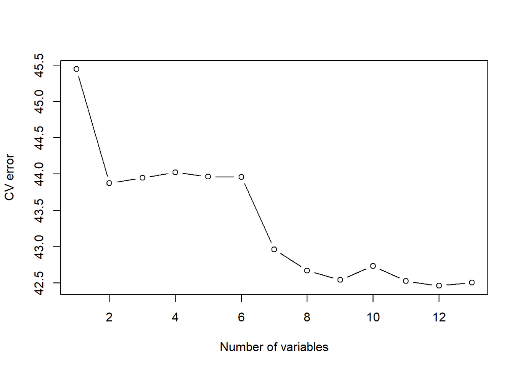

```r
# Best subset selection

# install libraries
install.packages("leaps", repos = "https://cran.rstudio.com/")
install.packages("glmnet", repos = "https://cran.rstudio.com/")
#load libraries
library(MASS)
library(leaps)
library(glmnet)

#load Boston Dataset
data(Boston)
set.seed(1) #set seed for reproducablility
predict.regsubsets = function(object, newdata, id, ...) {
    form = as.formula(object$call[[2]])
    mat = model.matrix(form, newdata)
    coefi = coef(object, id = id)
    xvars = names(coefi)
    mat[, xvars] %*% coefi
}

#k-fold cross-validation

k = 10 #10 folds
folds = sample(1:k, nrow(Boston), replace = TRUE) #assign each observation in boston dataset to one of the k folds
cv.errors = matrix(NA, k, 13, dimnames = list(NULL, paste(1:13))) #initilize matrix of MSE values
for (j in 1:k) { #loop through k folds of the cross validation
    best.fit = regsubsets(crim ~ ., data = Boston[folds != j, ], nvmax = 13)
    for (i in 1:13) { #loop through each variable in the dataset
        pred = predict(best.fit, Boston[folds == j, ], id = i) #make predictions
        cv.errors[j, i] = mean((Boston$crim[folds == j] - pred)^2) #calcuate MSE value of the prediction
    }
}
mean.cv.errors = apply(cv.errors, 2, mean)
plot(mean.cv.errors, type = "b", xlab = "Number of variables", ylab = "CV error")
```

```r
min(mean.cv.errors)
```

```
[1] 42.46014
```

```r
regfit.best = regsubsets(crim~., data=Boston, nvmax=13)
coef(regfit.best, 12)
```

```
  (Intercept)            zn         indus          chas           nox
 16.985713928   0.044673247  -0.063848469  -0.744367726 -10.202169211
           rm           dis           rad           tax       ptratio
  0.439588002  -0.993556631   0.587660185  -0.003767546  -0.269948860
        black         lstat          medv
 -0.007518904   0.128120290  -0.198877768
```

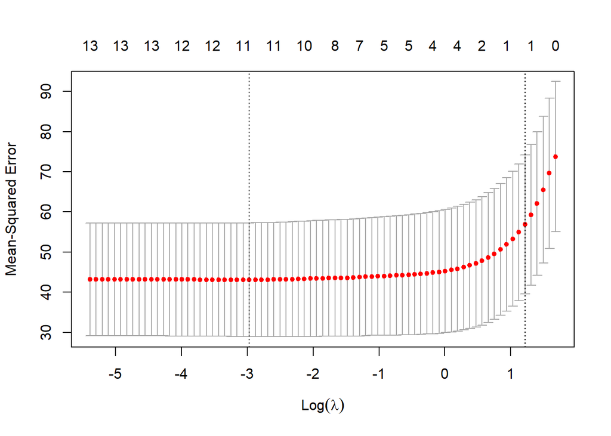

```r
#Lasso Regression

x = model.matrix(crim ~ ., Boston)[, -1]
y = Boston$crim
cv.out = cv.glmnet(x, y, alpha = 1, type.measure = "mse")
plot(cv.out)
```

```r
cv.out
```

```
Call:  cv.glmnet(x = x, y = y, type.measure = "mse", alpha = 1)

Measure: Mean-Squared Error

    Lambda Index Measure    SE Nonzero
min  0.051    51   43.11 14.16      11
1se  3.376     6   56.89 17.29       1
```

```r
#Ridge Regression

cv.out = cv.glmnet(x, y, alpha = 0, type.measure = "mse")
cv.out
```

```
Call:  cv.glmnet(x = x, y = y, type.measure = "mse", alpha = 0)

Measure: Mean-Squared Error

    Lambda Index Measure    SE Nonzero
min   0.54   100   43.48 14.33      13
1se  74.44    47   57.69 16.76      13
```

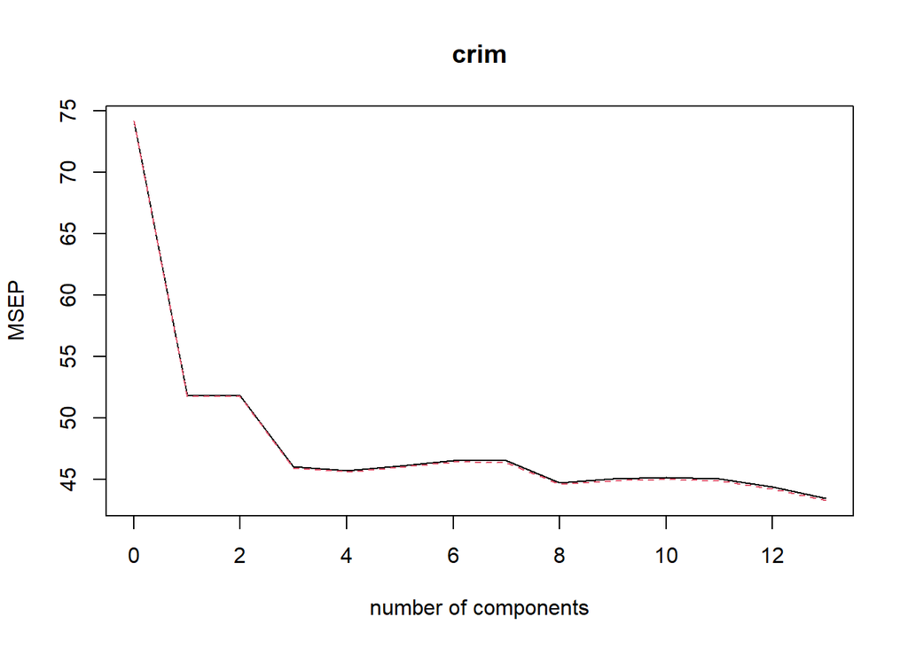

```r
#PCR

install.packages("pls", repos = "https://cloud.r-project.org/")
library(pls)
pcr.fit = pcr(crim ~ ., data = Boston, scale = TRUE, validation = "CV")
validationplot(pcr.fit, val.type = "MSEP")
```

Based on this data it seems that the best model for this data would be Best subset, as it had the lowest MSE value of 42.46014.

The best model is the 12 feature model from best subset selection. 1 feature is missing. This is because when running the best subset model the RMSE was found to be the lowest at 12 features. 13 features had a slightly higher MSE.